# Technology and Social Change

Lecture 9: How Technologies Emerge, Evolve, and Transform Society

Bogdan G. Popescu

bgpopescu@tec.mx

Tecnológico de Monterrey

# Framing the Problem

## A Puzzle to Start

In Lectures 5 and 8, we saw how specific technologies — the printing press and the steam engine — transformed economies and societies. Today we step back and ask a more fundamental question.

- A stick is not a technology
- A stick used as a lever to move a rock *is* a technology
- The stick didn’t change — so what did?

**The deeper question:** What makes something a *technology* — not just a thing?

## What We Usually Mean by “Technology”

Ask people what “technology” means and you get different answers:

- **Objects:** a computer, a bridge, a jet engine
- **Processes:** a surgical technique, an assembly line
- **Fields of knowledge:** biotechnology, nanotechnology
- **A vague force:** “technology is changing everything”

[figure not shown]

Planispheric Astrolabe (1654–55), Iran. Technologies span millennia — but what do they have in common? Source: Metropolitan Museum of Art (CC0).

All four are valid — but none explains *why* a stick-as-lever counts and a stick on the ground does not. Arthur argues they are all surface expressions of one deeper thing.

## Learning Objectives

By the end of this lecture, you will be able to:

1. **Define** technology as phenomenon exploitation
2. **Explain** combinatorial and recursive innovation
3. **Analyze** how domains structure innovation access
4. **Connect** Arthur’s framework to Polanyi’s crises
5. **Apply** these concepts to contemporary change

# Arthur’s Framework

## Arthur’s Definition of Technology

> “A technology is a means to fulfill a human purpose… a programming of phenomena to our use.”

> — W. Brian Arthur, *The Nature of Technology* (2009, p. 28)

Three key elements:

1. **Means** — technology is instrumental
2. **Human purpose** — exists relative to goals
3. **Programming of phenomena** — exploits natural effects

## The Concept of “Phenomena”

**Phenomenon:** A natural effect that is reliable, repeatable, and exploitable

Source: Arthur (2009, Ch. 3).

| Phenomenon | Technologies It Enables |
| --- | --- |
| Electromagnetic induction | Generators, motors, transformers |
| Fermentation | Beer, bread, antibiotics |
| Semiconductor properties | Transistors, computers, solar cells |

## Why Phenomena Matter

- One phenomenon can enable *many* technologies (see the table above)
- But observing a phenomenon is not enough to exploit it
  - Magnetism was observed for thousands of years
  - Only in 1831 did Faraday discover electromagnetic induction — the principle that made generators and motors possible
- The bottleneck is understanding *why* a phenomenon works, so engineers can harness it reliably

**Key insight:** Observation reveals a phenomenon; science explains it; engineering exploits it

## From Phenomenon to Technology

```
%%{init: {
  'theme': 'base',
  'themeVariables': {
    'fontSize': '22px',
    'primaryColor': '#ffffff',
    'primaryTextColor': '#000000',
    'primaryBorderColor': '#000000',
    'lineColor': '#000000',
    'secondaryColor': '#ffffff',
    'tertiaryColor': '#ffffff'
  },
  'flowchart': {
    'useMaxWidth': true,
    'nodeSpacing': 60,
    'rankSpacing': 80,
    'curve': 'basis'
  }
}}%%
flowchart LR
    A["Natural<br/>Effect"] -->|"Discovery"| B["Understood<br/>Phenomenon"]
    B -->|"Engineering"| C["Harnessed<br/>Technology"]
```

*Science enables discovery; engineering enables exploitation. Source: Arthur (2009, Ch. 2–3).*

## Magnetism: Known Since Antiquity

- **Thales of Miletus** (c. 624–546 BCE): lodestone attracts iron
- Attributed to a living, material property of the stone
- **Lucretius**, *De Rerum Natura* (~60 BCE): first written account of magnetic attraction

[figure not shown]

## What Lucretius Was Saying

**Original (c. 60 BCE):**

> *“First, stream there must from off the lode-stone seeds innumerable, a very tide, which smites by blows that air asunder lying betwixt the stone and iron.”*

> — Lucretius, *De Rerum Natura*, Book VI, ll. 998–1001 (trans. W.E. Leonard, 1916)

**In modern English:**

> The magnet constantly emits a stream of invisible particles that push aside the air between it and the iron, creating a void that pulls the iron toward the stone.

[figure not shown]

Lucretius pointing to the *casus* (chance). Source: Wikimedia Commons (public domain).

## The Phenomenon Without the Science

Lucretius also noted iron filings that *“seethe furiously”* near a magnet — an early observation of magnetic field lines.

**Key insight:** The ancients observed the phenomenon but lacked the mathematics to harness it. That had to wait ~1,900 years for Faraday.

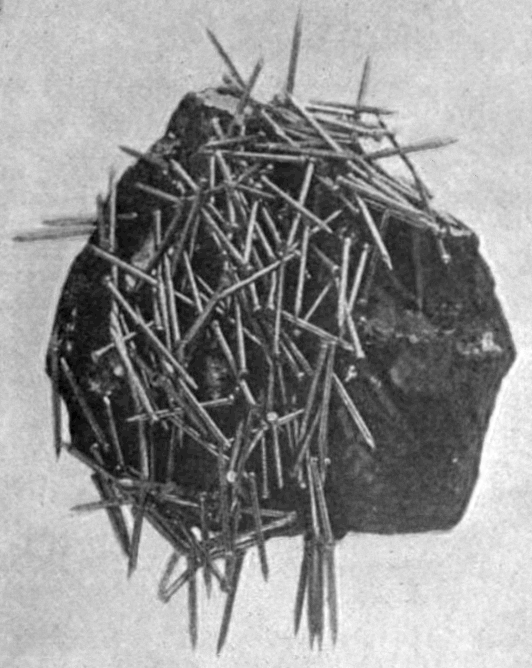

A lodestone attracting iron nails. Source: Wikimedia Commons (public domain).

## Case Study: Magnetism to the Electric Motor

- **Natural effect:** Magnetism (observed since antiquity)
- **Scientific understanding:** Faraday’s laws (1831)
- **First exploitation:** Early electric motors (1830s–40s)
- **Domain formation:** Electrical engineering (1880s)
- **Cascading technologies:** Grid, lighting, telecommunications

**2,000+ years** between observation and exploitation

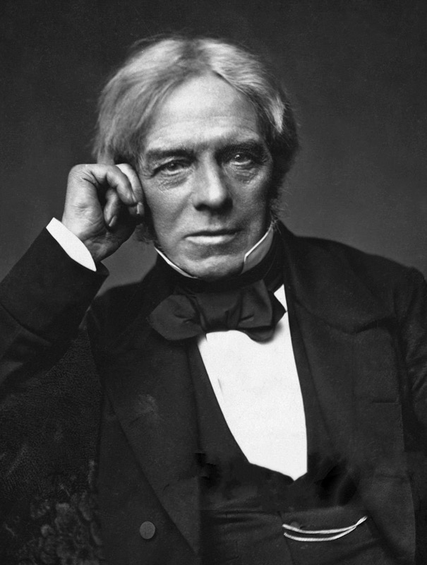

Michael Faraday (1791–1867): his discovery of electromagnetic induction in 1831 bridged millennia between observing magnetism and exploiting it. Source: Wikimedia Commons (public domain).

## Case Evidence: The First Electric Motor

[video not shown]

Source: https://www.youtube.com/watch?v=6Ns5tRyvoHY

1. What three inventions had to exist *before* Faraday could build the first motor?  
2. Once Faraday built the motor, he reversed the idea to invent what?  
3. What natural phenomenon does both the motor and the generator exploit?

## So What?

Technology begins with *nature*, not with *inventors*.

But a single phenomenon doesn’t explain the *acceleration* of innovation.

**Next:** The combinatorial principle explains why technology builds on itself.

# Combinatorial Innovation

## The Combinatorial Principle

> “Technologies inherit parts from the technologies that preceded them.”

> — Arthur (2009, p. 18)

**Key insight:** New technologies are built from *existing* technologies

- Innovation is recombination, not creation from nothing
- The “lone genius” myth obscures combinatorial reality
- More existing technologies → more possible combinations

## Anatomy of the Automobile

```
%%{init: {'theme': 'base', 'themeVariables': {'fontSize': '20px', 'primaryColor': '#4a7c6f', 'primaryTextColor': '#ffffff', 'lineColor': '#334155', 'primaryBorderColor': '#334155'}, 'flowchart': {'useMaxWidth': true, 'nodeSpacing': 40, 'rankSpacing': 60}}}%%
flowchart LR
    A["Internal<br/>Combustion<br/>Engine"] --> E["Automobile"]
    B["Wheel &<br/>Axle"] --> E
    C["Steering<br/>Mechanism"] --> E
    D["Transmission<br/>System"] --> E
    style A fill:#64748b,stroke:#334155,color:#fff
    style B fill:#64748b,stroke:#334155,color:#fff
    style C fill:#64748b,stroke:#334155,color:#fff
    style D fill:#64748b,stroke:#334155,color:#fff
    style E fill:#4a7c6f,stroke:#334155,color:#fff
```

*Every component was itself a prior technology. Source: Arthur (2009, Ch. 1).*

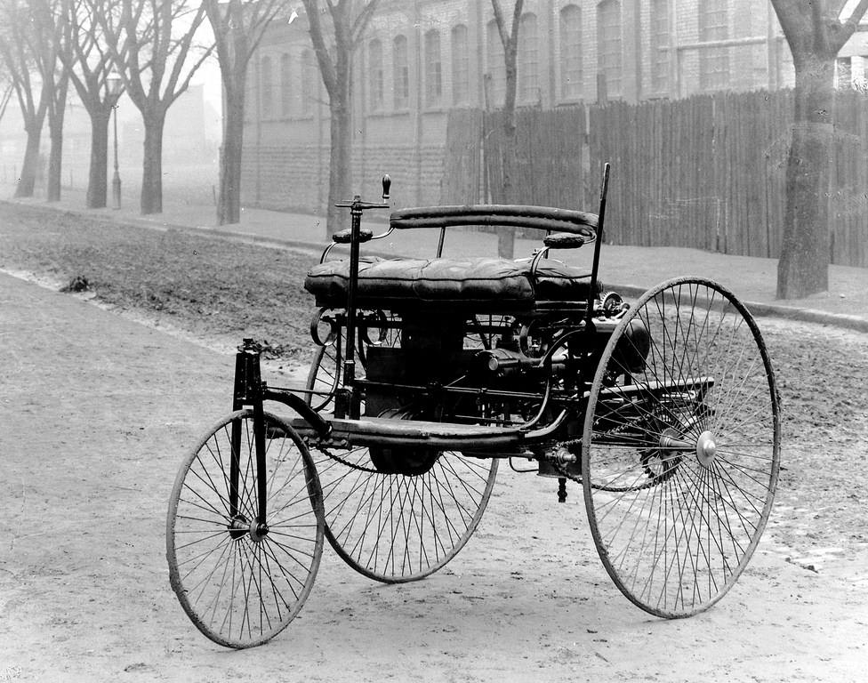

The Benz Patent-Motorwagen (1886): the first automobile combined the internal combustion engine, wheels, steering, and transmission — all existing technologies. Source: Wikimedia Commons (public domain).

## The Recursive Structure

**Technologies create conditions for further technologies:**

1. New technologies provide new **components** for combination
2. New technologies reveal new **phenomena** to exploit
3. New technologies create new **problems** requiring solutions

> “Technology creates itself out of itself.” — Arthur (2009, p. 175)

## The Innovation Cycle

```
%%{init: {
  'theme': 'base',
  'themeVariables': {
    'fontSize': '22px',
    'primaryColor': '#ffffff',
    'primaryTextColor': '#000000',
    'primaryBorderColor': '#000000',
    'lineColor': '#000000',
    'secondaryColor': '#ffffff',
    'tertiaryColor': '#ffffff'
  },
  'flowchart': {
    'useMaxWidth': true,
    'nodeSpacing': 60,
    'rankSpacing': 80,
    'curve': 'basis'
  }
}}%%
flowchart LR
    A["Existing<br/>Technologies"] -->|"Combine"| B["New<br/>Technology"]
    B -->|"Provides new<br/>components"| C["Expanded<br/>Toolbox"]
    C -->|"Enables"| A
    B -->|"Reveals new<br/>phenomena"| D["New<br/>Possibilities"]
    D -->|"Feeds back"| A
    B -->|"Creates new<br/>problems"| E["New<br/>Demands"]
    E -->|"Drives"| A
    style A fill:#4a7c6f,stroke:#334155,color:#fff
    style B fill:#b44527,stroke:#334155,color:#fff
    style C fill:#b7943a,stroke:#334155,color:#fff
    style D fill:#b7943a,stroke:#334155,color:#fff
    style E fill:#b7943a,stroke:#334155,color:#fff
```

*Author’s illustration based on Arthur (2009).*

## Technology Adoption Accelerates Over Time

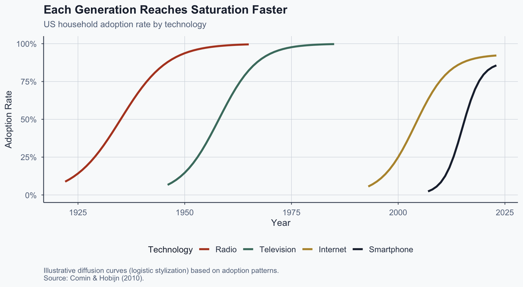

## Path Dependence and Lock-In

- Existing technologies shape what *can* exist next
- Early choices constrain later possibilities
- Mature technologies resist displacement
- Switching costs often exceed improvement benefits

**Classic case:** QWERTY persists not because it is optimal, but because of the installed base (David, 1985; Arthur, 1994).

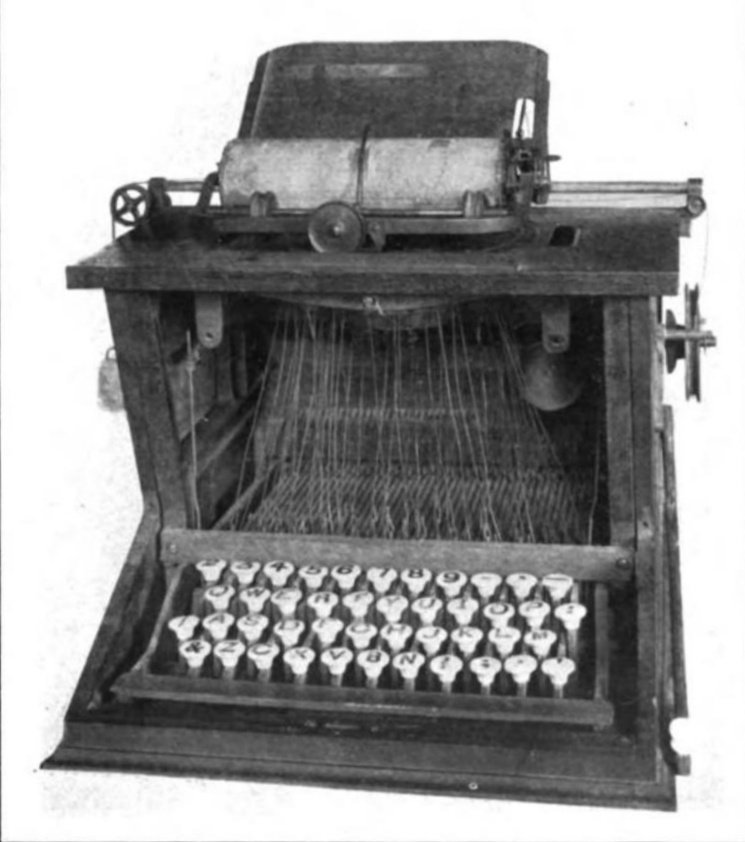

The Sholes & Glidden Type-Writer (1873) — the first commercial typewriter and origin of the QWERTY layout. Source: George Iles, *Leading American Inventors* (1912), public domain.

## Path Dependence and Lock-In

- Existing technologies shape what *can* exist next
- Early choices constrain later possibilities
- Mature technologies resist displacement
- Switching costs often exceed improvement benefits

Recall from Lecture 5: the Ottoman Empire resisted the printing press for nearly 290 years — incumbent scribal guilds locked in manuscript technology.

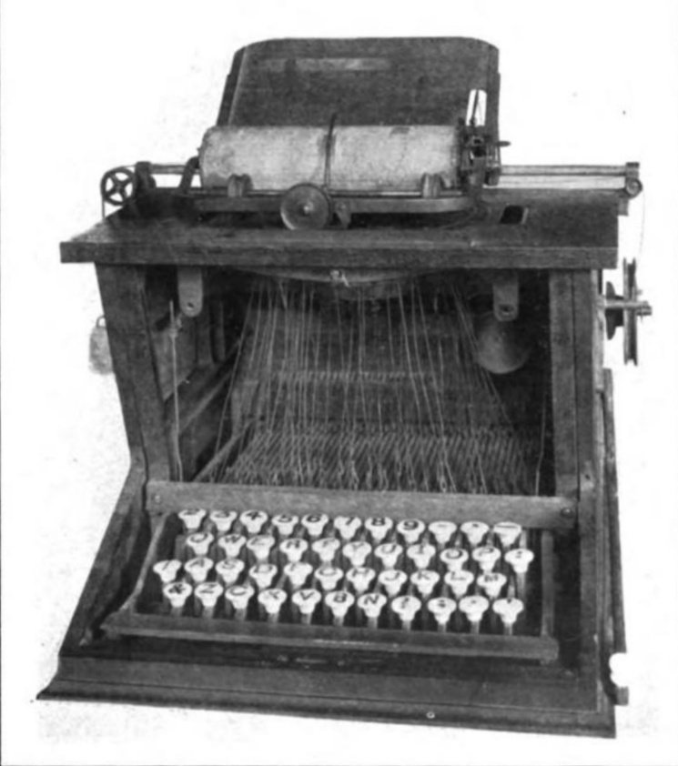

The Sholes & Glidden Type-Writer (1873) — the first commercial typewriter and origin of the QWERTY layout. Source: George Iles, *Leading American Inventors* (1912), public domain.

# Technology Domains

## What Are Domains?

**Domain:** A cluster of technologies sharing phenomena and methods

Each domain has:

- **Vocabulary:** Available components and devices
- **Grammar:** Rules for combining vocabulary elements

**Key insight:** Expertise rarely transfers across domains

## Domain Examples: Electronics vs. Biotech

**Electronics:**

- *Vocabulary:* transistors, resistors, circuits
- *Grammar:* Ohm’s law, Boolean logic

**Biotechnology:**

- *Vocabulary:* enzymes, cell cultures, genes
- *Grammar:* molecular biology, gene expression

Knowing electronics grammar does not help with biotech problems

## Time to Market Varies by Domain

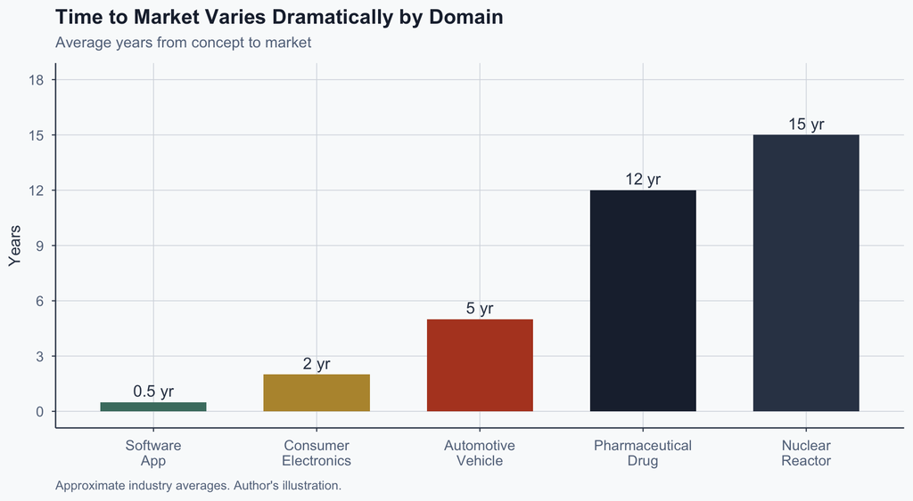

## Why Places Specialize

Why does Silicon Valley do software while Boston does biotech?

- Knowledge accumulates locally over time
- Domain-skilled workers cluster geographically
- Specialized suppliers co-locate nearby
- Universities and labs specialize by domain
- Tacit knowledge transfers through proximity

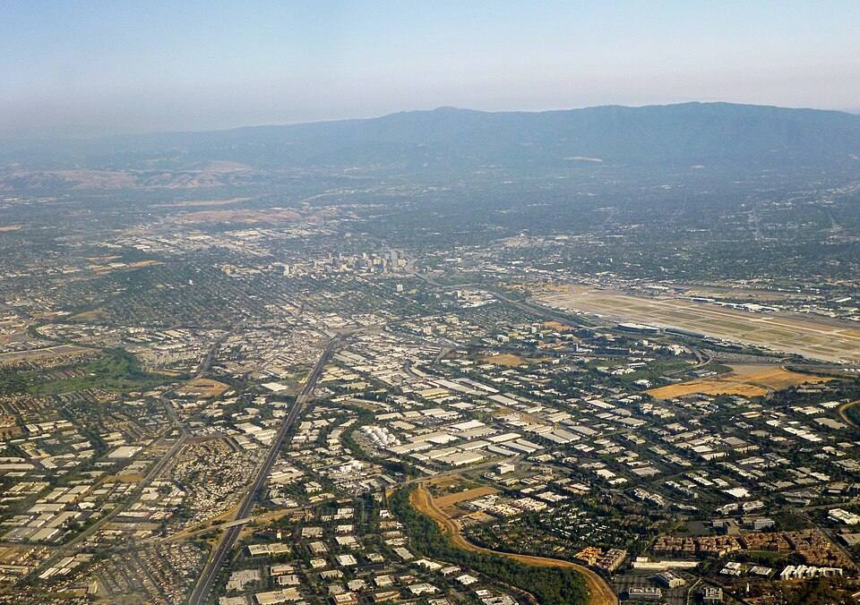

Silicon Valley, looking south along I-880 toward downtown San Jose. Geographic clustering of tech firms is a hallmark of domain specialization. Photo: Coolcaesar (2014), CC BY-SA 3.0.

## Why Places Specialize

**This is path-dependent:** early advantages compound (Saxenian, 1994)

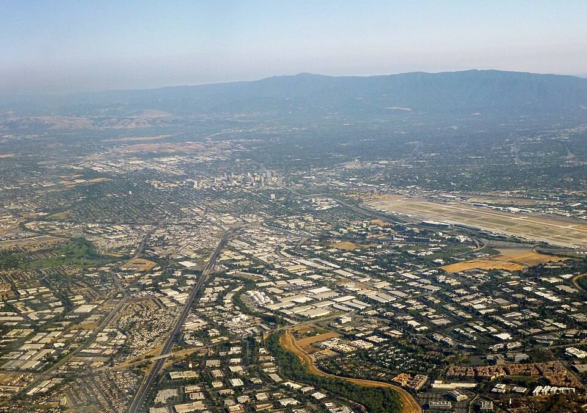

Silicon Valley, looking south along I-880 toward downtown San Jose. Geographic clustering of tech firms is a hallmark of domain specialization. Photo: Coolcaesar (2014), CC BY-SA 3.0.

## Domain Boundaries and Innovation

**Most innovation happens *within* domains:**

- Incremental improvements using existing vocabulary
- New combinations of existing components

**But breakthroughs often emerge at boundaries:**

- Combining knowledge from multiple domains
- Bioinformatics = biology + computation
- Fintech = finance + software

## So What?

Domains explain *why* different places innovate differently.

But technology doesn’t evolve in isolation—it reshapes economy and society.

**Next:** How technology and economy co-evolve, and when this triggers crisis.

# Co-evolution and Social Change

## Economy and Technology Co-evolve

> “The economy creates the atmosphere in which technologies develop, and the technologies in turn alter the economy.”

> — Arthur (2009, Ch. 9–10)
- **Technology → Economy:** new products, changed costs
- **Economy → Technology:** demand signals, investment
- Neither determines the other—they evolve together

## The Co-evolution Loop

```
%%{init: {
  'theme': 'base',
  'themeVariables': {
    'fontSize': '22px',
    'primaryColor': '#ffffff',
    'primaryTextColor': '#000000',
    'primaryBorderColor': '#000000',
    'lineColor': '#000000',
    'secondaryColor': '#ffffff',
    'tertiaryColor': '#ffffff'
  },
  'flowchart': {
    'useMaxWidth': true,
    'nodeSpacing': 60,
    'rankSpacing': 80,
    'curve': 'basis'
  }
}}%%
flowchart LR
    A["Technology<br/>System"] -->|"Creates products,<br/>changes costs"| B["Economic<br/>Structure"]
    B -->|"Demand signals,<br/>investment"| A
    B -->|"Disrupts jobs<br/>& communities"| C["Social<br/>Order"]
    C -->|"Regulation &<br/>counter-movements"| B
    style A fill:#4a7c6f,stroke:#334155,color:#fff
    style B fill:#b7943a,stroke:#334155,color:#fff
    style C fill:#b44527,stroke:#334155,color:#fff
```

*Technology, economy, and society form an interconnected system. Author’s illustration.*

## Bridge to Polanyi

Polanyi’s *The Great Transformation* (1944) provides the crisis framework:

1. Economy is “embedded” in society
2. “Disembedding” creates social destruction
3. Society responds with counter-movements
4. This “double movement” reshapes political orders

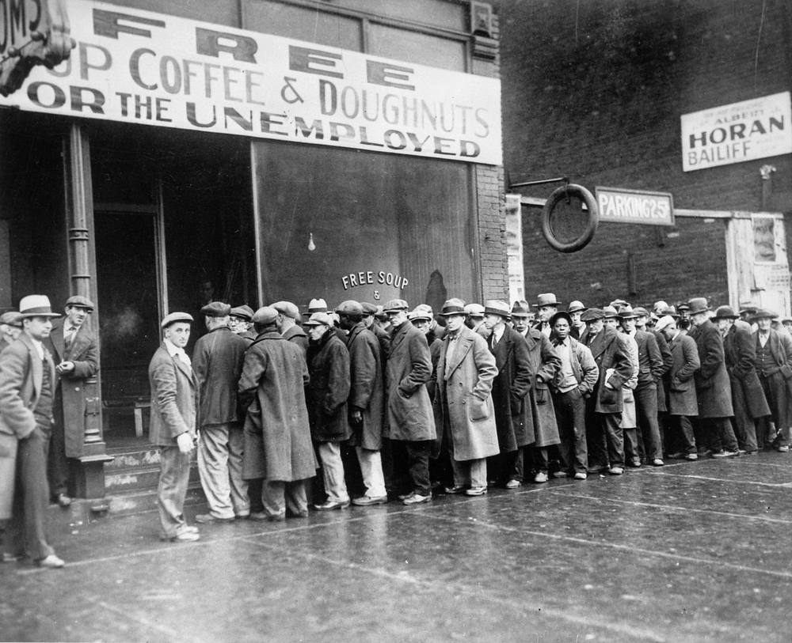

Unemployed men queued outside a soup kitchen in Chicago, February 1931. The Great Depression exemplified the social destruction Polanyi described. Source: NARA / Wikimedia Commons (public domain).

## The Double Movement

```
%%{init: {
  'theme': 'base',
  'themeVariables': {
    'fontSize': '22px',
    'primaryColor': '#ffffff',
    'primaryTextColor': '#000000',
    'primaryBorderColor': '#000000',
    'lineColor': '#000000',
    'secondaryColor': '#ffffff',
    'tertiaryColor': '#ffffff'
  },
  'flowchart': {
    'useMaxWidth': true,
    'nodeSpacing': 60,
    'rankSpacing': 80,
    'curve': 'basis'
  }
}}%%
flowchart LR
    A["Market<br/>Expansion"] -->|"Commodifies labor,<br/>land, money"| B["Social<br/>Disruption"]
    B -->|"Generates<br/>resistance"| C["Counter-<br/>Movement"]
    C -->|"Regulation &<br/>protection"| D["Re-embedding"]
    D -->|"Constrains"| A
    style A fill:#b7943a,stroke:#334155,color:#fff
    style B fill:#b44527,stroke:#334155,color:#fff
    style C fill:#4a7c6f,stroke:#334155,color:#fff
    style D fill:#1e293b,stroke:#334155,color:#fff
```

*Polanyi’s double movement is a recurring historical cycle. Source: Polanyi (1944).*

## When Change Becomes Crisis

**Connecting Arthur to Polanyi:**

When technological change enables rapid economic reorganization:

- Workers displaced faster than retraining allows
- Communities lose their economic base
- Existing protections become inadequate
- Political counter-movements emerge

**Historical parallels:** In Lecture 8, we saw this cycle in the Industrial Revolution: Engels’ Pause (1790s–1840s) was the disruption; Factory Acts and trade unions were the counter-movement. The Second Industrial Revolution (1870s–1930s) repeated the pattern.

## Exercise: Applying Polanyi Today

**Prompt:** Choose a current technology (AI, gig platforms, social media).

1. What “disembedding” effects has it produced?
2. What counter-movements have emerged?
3. Is re-embedding happening? How?

**Discuss in small groups for 5 minutes.**

## So What?

Technology is not neutral—it reshapes social arrangements.

Understanding *how* it evolves helps us anticipate *when* crises emerge.

**Next:** Let’s synthesize everything into an analytical toolkit.

# Synthesis

## Key Takeaways

1. **Technology is phenomenon exploitation**—not gadgets
2. **Innovation is combinatorial and recursive**—self-accelerating
3. **Domains structure who can innovate**—geography, capital, expertise
4. **Technology and economy co-evolve**—neither determines the other
5. **Rapid change triggers Polanyian crises**—counter-movements emerge

# References

## References

- Arthur, W. B. (1994). *Increasing returns and path dependence in the economy*. University of Michigan Press.
- Arthur, W. B. (2009). *The nature of technology: What it is and how it evolves*. Free Press.
- Comin, D., & Hobijn, B. (2010). An exploration of technology diffusion. *American Economic Review*, *100*(5), 2031–2059.
- David, P. A. (1985). Clio and the economics of QWERTY. *American Economic Review*, *75*(2), 332–337.
- Mokyr, J. (2002). *The gifts of Athena: Historical origins of the knowledge economy*. Princeton University Press.
- Polanyi, K. (1944). *The great transformation*. Farrar & Rinehart.
- Schumpeter, J. A. (1942). *Capitalism, socialism and democracy*. Harper & Brothers.
- Saxenian, A. (1994). *Regional advantage: Culture and competition in Silicon Valley and Route 128*. Harvard University Press.